# prob5 slides

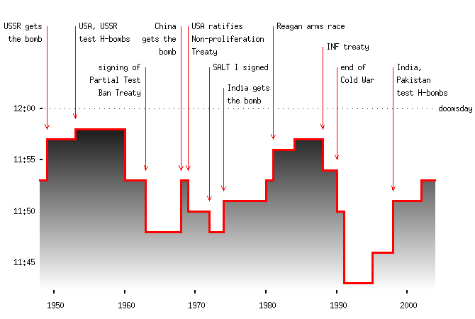

```python
from IPython.display import display, Image

display(Image(filename = '/home/neal/Pictures/doomsday.png'))
```

Although this may seem like a two-dimensional visualization, time along the x-axis is changing at a constant rate and can be ignored as a seperate dimension.

[figure not shown]

```python
display(Image(filename = '/home/neal/Pictures/2dScalarField.png'))
```

The first dimension is "time of year", measured in months around the perimeter of the graph. The second dimension is "the year", measured in colors given by the key in the bottom left. At specific points across these two dimensions there is a scalar given by a radius which reports how popular apricots were at the specified year and time of year based on number of google searches.

[figure not shown]

```python
display(Image(filename = '/home/neal/Pictures/3dScalarField.jpg'))
```

We have three dimensions (call them x,y,z), and there is a color associated with each three-dimensional coordinate.

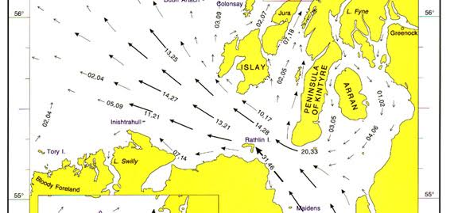

```python
display(Image(filename = '/home/neal/Pictures/2dVectorField.jpeg'))
```

The two dimensions are longitude and latitude. At specific locations we are given the magnitude and direction of tidal flows in the Scottish Isles and surrounding areas.

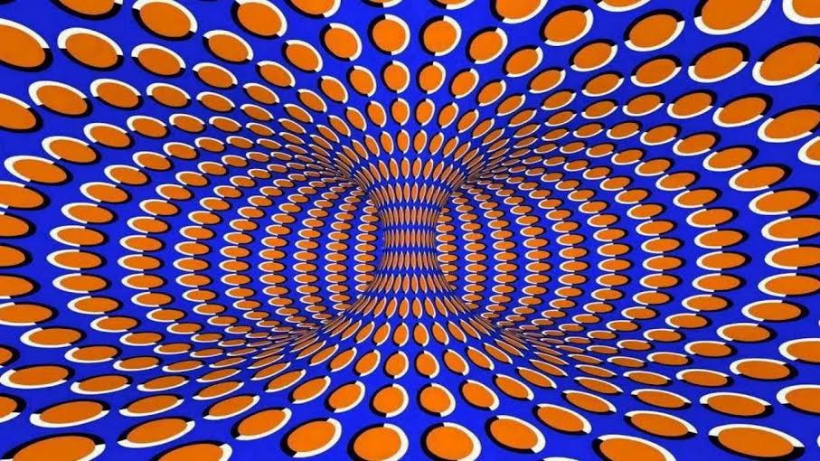

```python
display(Image(filename = '/home/neal/Pictures/3dShape.jpg'))
```

This three-dimensional visualization was designed in such a way to make the viewer perceive movement. This image does not have any data attributes so it is nothing more than a three-dimensional shape.

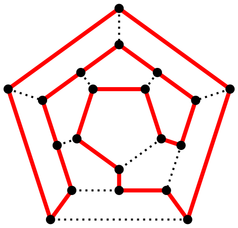

```python
display(Image(filename = '/home/neal/Pictures/graph.png'))
```

This is a graph (a set of vertices and edges). It is not a tree because it contains at least one cycle.